# La varita de caramelo

El kiosquero se encogió de hombros mientras daba el *Sur* y una varita de caramelo al padre de dos energúmenos que miraban voraces hacia arriba. Este sujetó la chuchería por los extremos y, haciendo presión en el centro con los pulgares *¡CRACK!* la partió en dos.

— ¡Para mí la grande! —gritó Simona.

— ¡No! ¡La grande para mí! —chilló Arturo.

— Venga, venga, que son iguales —mintió el progenitor mientras asignaba las dulces fracciones—. Hala, vámonos al parque.

Sentado en su banco preferido, con el rabillo del ojo pendiente de los columpios, hojeó el periódico. Como siempre, solo traía noticias nefastas, maquiavélicas o absurdas: *«El Titanic se hunde frente a Terranova», «El Krakatoa devasta la isla de Java», «La peste bubónica asola Londres», «WC-gate en los madriles», «Gengis Khan invade el Imperio austrohúngaro», «El boniato por las nubes», «El doctor Zhivago consigue el MIR a los ciento tres años», «El cine español en su mejor momento»…* Enseguida llegó a la penúltima página, su favorita y la única razón que mantenía el ritual del diario dominguero.

Antes lo hacía, pero ya se había cansado del yunque de platero y de la antigua nota musical, así que pasó directamente al *sudoku*. El fascinante cuadrado aritmético y su magia alrededor del 9. Nueve filas, nueve columnas, nueve cuadrados, nueve guarismos engarzados con armonía sobrenatural. Enigmático nueve. De haberse conocido en el siglo V a. C. tal vez Pitágoras habría abandonado la *tetraktys*, el 10 y sus triángulos al caer en brazos del sudoku, el 9 y los cuadrados, fundando la secta de *los nonainos*, seguramente. El 9 le gustaba. Cuando estaba en el colegio siempre sacaba nueves, ¿habría sido más feliz si hubiese sacado dieces? Estaba seguro de que no. El nueve estaba muy cerca de la perfección, lo que suponía un estímulo para perseverar, para mantener el interés, la curiosidad, las ganas de seguir. Y estaba lo suficientemente lejos como para evitar la soberbia y autocomplacencia del engreído. Sin duda, una vida de 9 era mucho mejor que una de diez.

Acabado el rompecabezas, volvió a mirar hacia los columpios. Simona era su preferida. Era la mayor y una mini réplica de su madre, perpicaz y ladina, guapa y encantadora. Arturo era más simplón y se le veía venir; además, cada vez se parecía más al butanero local. Incluso tuvieron que llevarlo al pediatra para revisar una deviación de cervicales y clavícula derecha. Ahora que las ideas de Lamarck habían saltado de nuevo a la palestra científica, la sospecha epigenética no ayudaba precisamente a promover el cariño hacia su supuesto vástago. Aún así, los quería a ambos por igual y no pudo evitar cierta reconcomilla por haber dado el trozo grande a la niña.

Es que era muy difícil partir algo exactamente por la mitad y no podía evitar la preferencia filial. Aún así, tal vez podría entrenarse. Como quedaba parque para rato, rasgó una tira del borde del diario y la sostuvo con el pulgar e índice de cada mano, en tensión, sujeta por los extremos. Estiró un poco más y *¡PLAFF!* Se partió inopinadamente, tal como esperaba, en dos trozos desiguales. Depositó cada trozo a sendos lados del banco y repitió el experimento. La tira se rompía por cualquier sitio, a veces más cerca de la mano izquierda, a veces de la derecha, a veces casi por el centro. Pacientemente, ante la atónita mirada de la pareja de abuelillos del banco vecino, fue amontonando recortes a diestro y siniestro. Al rato, el montón de papelillos a su derecha era prácticamente igual que el de la izquierda. «Ya me lo imaginaba».

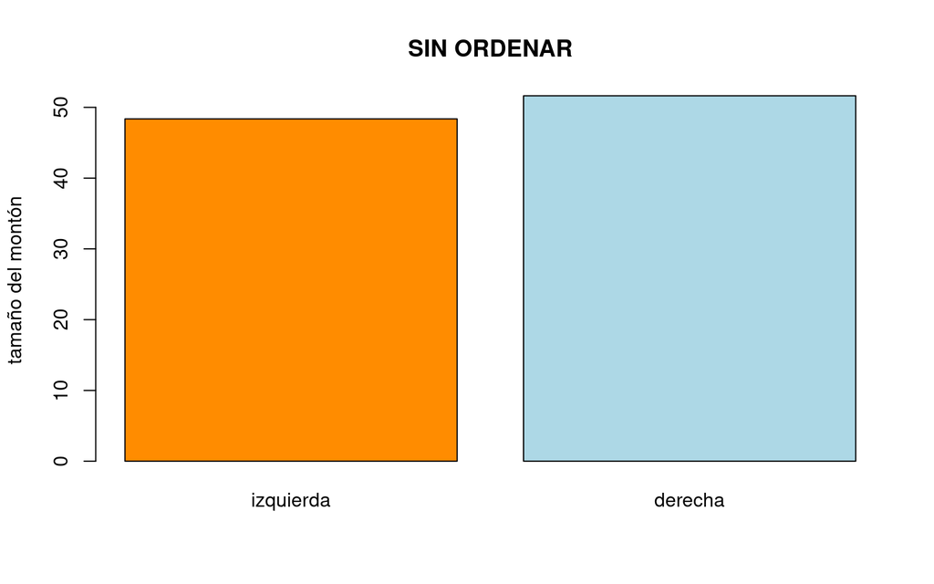

```r
n <- 100  # número de tiras

#---- PRIMERO, SIN ORDENAR
izq <- runif(n)
dch <- 1 - izq
monton_izq <- sum(izq)
monton_dch <- sum(dch)
barplot(c(monton_izq, monton_dch), names.arg = c("izquierda", "derecha"), col = c("darkorange",
    "lightblue"), ylab = "tamaño del montón", main = "SIN ORDENAR")
```

**Figura 1. Papel acumulado a cada lado cuando se colocan al azar.** Como se esperaba, más o menos la mitad en cada montón.

Hizo una bola con los recortes y la echó a la papelera. Entonces, con cierta sensación de culpa, cambió el experimento: ahora colocaría el trozo más grande a su izquierda y el más corto a la derecha. Aunque su esperanza como padre estaba en que no hubiera mucha diferencia, al cabo del tiempo el montón de la izquierda triplicaba al de la derecha.

«¡El triple!» No se lo habría imaginado aunque, ahora que lo pensaba, la explicación era sencilla: al ordenar los trozos, el más corto siempre sería inferior a la mitad de la tira, es decir, el punto de rotura quedaría entre 0 y 0.5, con una media de 0.25. Por eso el trozo largo era, con 0.75 en promedio, tres veces más largo que el corto.

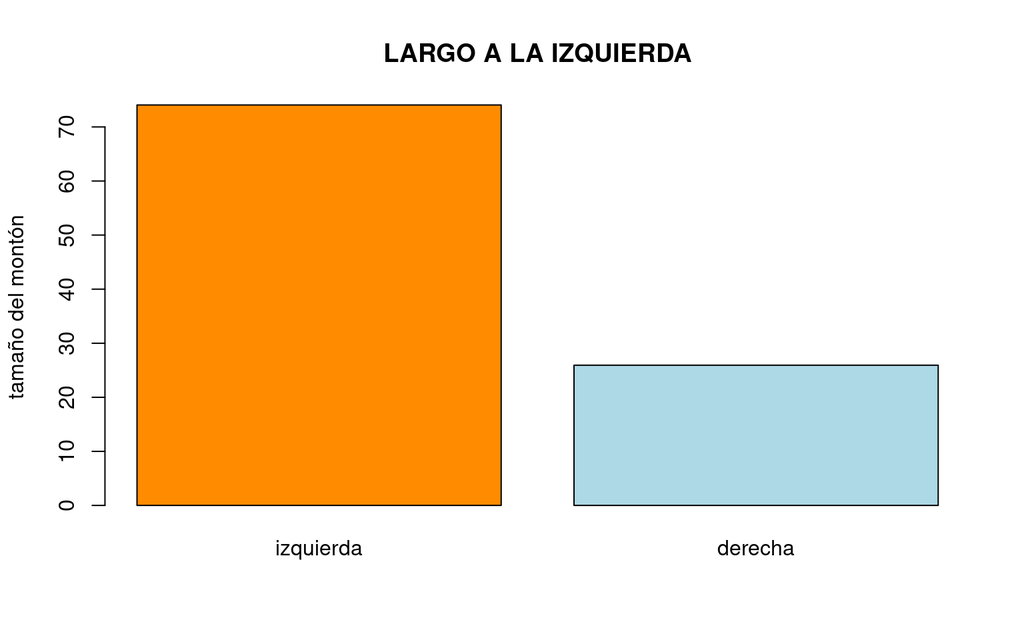

```r
#---- AHORA, EL MÁS GRANDE A LA IZQUIERDA
for (i in 1:n) {
    izq[i] <- runif(1)
    if (izq[i] < 0.5) {
        izq[i] <- 1 - izq[i]
    }
    dch[i] <- 1 - izq[i]
}
monton_izq <- sum(izq)
monton_dch <- sum(dch)
barplot(c(monton_izq, monton_dch), names.arg = c("izquierda", "derecha"), col = c("darkorange",
    "lightblue"), ylab = "tamaño del montón", main = "LARGO A LA IZQUIERDA")
```

**Figura 2. Papel acumulado a cada lado cuando el largo se coloca a la izquierda.** Sorprendentemente (o no) el montón de la izquierda triplica al otro.

En ese instante se sintió como el *demonio de Maxwell*. A sabiendas de que cometía cierta injusticia, no se imaginaba hasta qué grado sumo se estaba manifestando. ¡La acumulación de pequeñas preferencias, aparte de infringir la segunda ley de la termodinámica, acabaría con Simone en el dentista!

# Formalización del asunto

Cuando la varita se parte en dos segmentos $a_1$ y $a_2$ según hemos visto, el mayor $a_1$ tendrá como mínimo una longitud $\frac{1}{2}$ a lo que habrá que añadir el trozo que pierda el segmento corto con respecto a la mitad, esto es $\frac{1}{4}$. Y al más corto $a_2$ le quedará el cuarto restante. Gráficamente:

[figure not shown]

**Figura 3. Longitudes esperadas con un punto de fractura si siempre se coloca el mayor a la izquierda.** Sorprendentemente (o no) el montón de la izquierda triplica al otro.

Es decir:

$$\begin{align}
a_1 &= \frac{1}{2} + \frac{1}{4} = \frac{3}{4} \\[1em]
a_2 &= \frac{1}{4}
\end{align}$$

## ¿Y con tres segmentos?

La varita se partirá en 3 segmentos si elegimos 2 puntos de fractura. Si no los ordenamos, se esperarían tres fragmentos iguales de un tercio. Al ordenarlos, aplicamos el razonamiento de arriba y podemos ver que, en promedio, el trozo más pequeño será $\frac{1}{3}$ del tercio que le correspondería por azar, es decir, $\frac{1}{9}$. El trozo mediano recibiría la mitad de su tercio (esto es, $\frac{1}{6}$) y, el grande, su tercio completo. Los restos (a saber, $\frac{1}{9}, \frac{1}{9}, \frac{1}{6}$) se repartirían de modo inícuo, como muestra la Figura 4.

[figure not shown]

**Figura 4. Longitudes esperadas con dos puntos de fractura y se ordenan de mayor a menor.** Empieza a vislumbrarse la suma de armónicos.

## Caso general

Llamaremos $n$ al número de segmentos y $a_r$ a la longitud de cada uno ordenados en rango de mayor a menor $r = \{1, 2, \cdots, n\}$. Ahora aplicamos nuestra intuición al patrón de armónicos y nos tiramos a la piscina:

$$a_r = \frac{1}{n} \sum_{i=r}^{n} \frac{1}{i}$$
Veámosla en acción:

- $n = 2$: $a_1 = \frac{1 + \frac{1}{2}}{2} = 0.75$; $a_2 = \frac{\frac{1}{2}}{2} = 0.25$
- $n = 3$: $a_1 = \frac{1 + \frac{1}{2} + \frac{1}{3}}{3} = 0.61$; $a_2 = \frac{\frac{1}{2}+ \frac{1}{3}}{3} = 0.28$; $a_3 = \frac{\frac{1}{3}}{3} = 0.11$
- etc.

Como es natural, esto ya se conocía desde hace mucho tiempo, aunque la formulación original es $a_r = \frac{1}{n} \sum_{i=1}^{r} \frac{1}{n - i + 1}$ con el rango de menor a mayor longitud. La demostración formal aparece en [este artículo](https://rss.onlinelibrary.wiley.com/doi/abs/10.1111/j.2517-6161.1956.tb00213.x) (al final de la página 81) y parece que está también está deducida por inducción. En ese artículo se exploran más casos y propiedades que superan con creces mi limitada capacidad, aunque con lo anterior me basta por ahora. A riesgo de parecer petulante, me quedaré con la forma basada en la suma de armónicos porque me parece más bonita.

## El bestia y la bella

Aunque en este caso no hay motivos para sospechar, siempre es gratificante echar un rato de programación para ir ordenando ideas que luego aparecerán. Veamos si coinciden la aproximación a base de fuerza bruta y la otra más *armoniosa*.

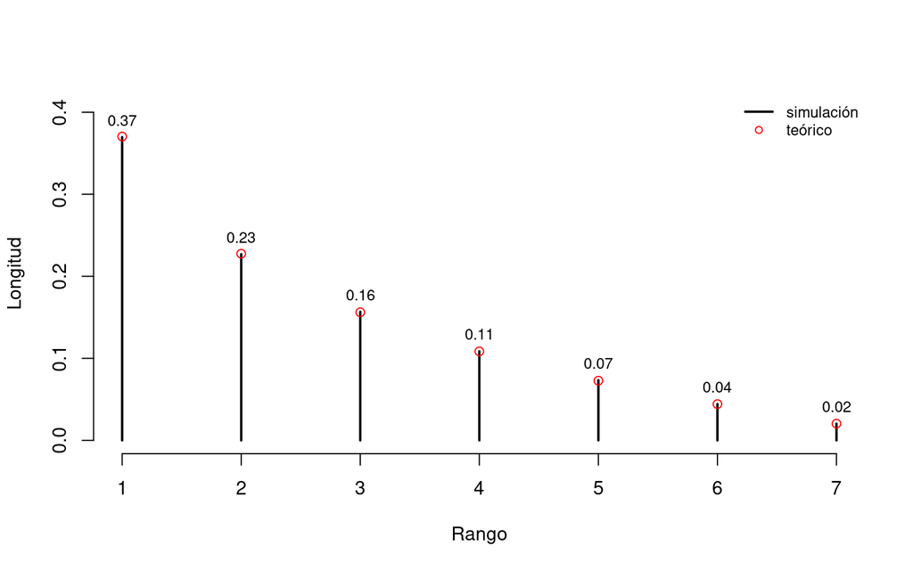

```r
# PRIMERO A LO BESTIA
repetir <- 10000
n <- 7
trozos <- numeric(n)
as <- matrix(NA, nrow = n, ncol = repetir)  # para guardar las repeticiones
#
for (i in 1:repetir) {
    p_azar <- runif(n - 1)  # elegir los puntos de corte al azar
    p_azar <- c(sort(p_azar), 1)  # ordenar los cortes, más el final
    trozos[1] <- p_azar[1]  # primer trozo
    for (j in 2:n) {
        trozos[j] <- p_azar[j] - p_azar[j - 1]  # los demás trozos
    }
    trozos <- sort(trozos, decreasing = TRUE)  # ordenarlos de mayor a menor
    as[, i] <- trozos
}
#
distribucion <- rowMeans(as)  # longitudes medias
# gráfico
plot(1:n, distribucion, lwd = 2, bty = "n", xlab = "Rango", ylab = "Longitud", type = "h",
    ylim = c(0, 1.1 * max(distribucion)))
text(1:n, distribucion, round(distribucion, 2), cex = 0.8, pos = 3)
legend("topright", bty = "n", cex = 0.8, c("simulación", "teórico"), lty = c(1,
    0), lwd = c(2, NA), pch = c(NA, 1), col = c("black", "red"))

# AHORA LA BELLA para hacer la suma de armónicos
sum_arm <- function(n) {
    a <- numeric(n)
    for (i in 1:n) {
        for (j in 1:i) {
            a[j] <- a[j] + 1/i
        }
    }
    a/n
}
#
points(sum_arm(n), col = "red")
```

**Figura 5. Distribución de longitudes esperadas.** La barrita negra representa la media de 10000 simulaciones según el código anterior. El círculo rojo es el valor según la ecuación teórica.

# Aplicado a la distribución de especies

Con mucha vista e intuición, [Robert MacArthur](https://www.pnas.org/content/43/3/293) pensó que, si la línea representaba el recurso compartido por varias especies similares y estas se repartían los nichos como fragmentos al azar del mismo, entonces sus abundancias deberían seguir la misma distribución. Este *modelo de MacArthur o del bastón roto* se hizo famoso en ecología y se comprobó que, *más o menos*, se cumplía en algunas comunidades de pájaros y otras de peces. Algunos años después [se demostró](https://www.sciencedirect.com/science/article/pii/S0022519376800276) que otros axiomas independientes del recurso también conducían a la misma distribución, como cuando los valores proceden de una distribución exponencial con ciertas propiedades.

## Ejemplos con fitoplancton

Pájaros no tengo, pero especies de fitoplancton sí. En la Figura 6 se muestra el contaje de especies fitoplanctónicas en una muestra de agua mediterránea y el modelo teórico correspondiente.

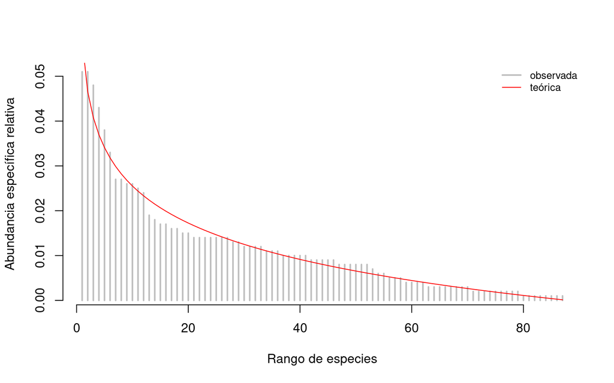

```r
fito <- c(51, 51, 48, 43, 38, 33, 27, 27, 26, 26, 25, 24, 19, 18, 17, 17, 16, 16,
    15, 15, 14, 14, 14, 14, 14, 14, 14, 13, 13, 12, 12, 12, 12, 11, 11, 11, 10, 10,
    10, 10, 10, 9, 9, 9, 9, 9, 8, 8, 8, 8, 8, 8, 7, 6, 6, 5, 5, 5, 4, 4, 4, 4, 3,
    3, 3, 3, 3, 3, 3, 3, 2, 2, 2, 2, 2, 2, 2, 2, 2, 1, 1, 1, 1, 1, 1, 1, 1)
fito <- fito/sum(fito)
n <- length(fito)
plot(fito, type = "h", lwd = 2, bty = "n", xlab = "Rango de especies", ylab = "Abundancia específica relativa",
    col = "grey")
lines(sum_arm(n), col = "red")
legend("topright", bty = "n", cex = 0.8, c("observada", "teórica"), lwd = c(2, 1),
    col = c("grey", "red"))
```

**Figura 6. Distribución de abundancias de fitoplancton** en una muestra de 250 ml tomada en el mar de Alborán . En rojo se representa el valor teórico para $n$ = 87 según el *modelo del bastón roto*.

El parecido no está mal, podríamos decir que la hipótesis del reparto aleatorio de nichos es bastante certera en esa muestra. Desafortunadamente, no siempre se cumple, veamos en la Figura 7 otra muestra del mismo mar, que aparece en [este artículo](https://digital.csic.es/bitstream/10261/164645/1/Margalef_1994.pdf) donde el famoso Margalef se encomendó a santa Linotipia y martirizó a los editores con un anexo kilométrico.

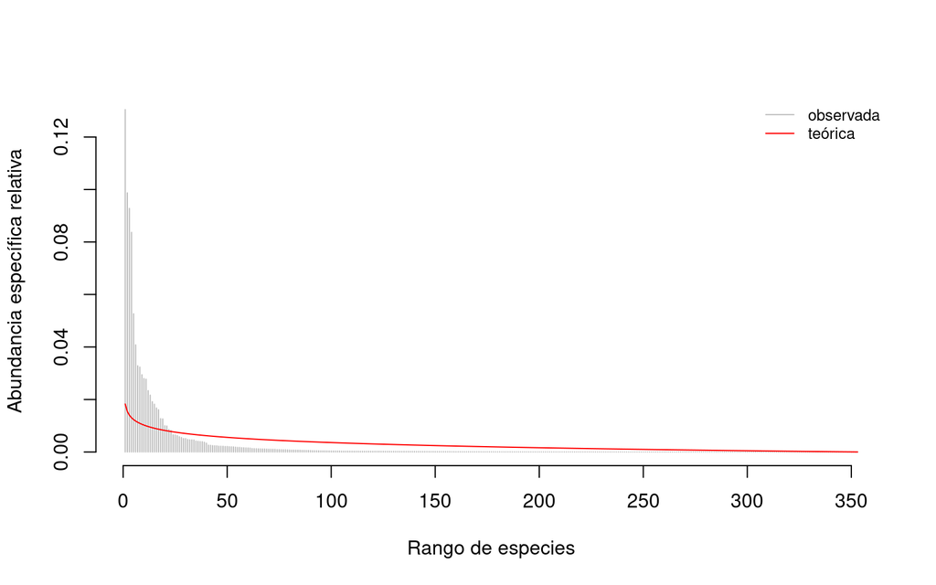

**Figura 7. Otra distribución de abundancias de fitoplancton** en otra muestra del mismo mar (datos extraídos de [aquí](https://digital.csic.es/bitstream/10261/164645/1/Margalef_1994.pdf)). Vemos que no siempre funciona el asunto.

Cuando una hipótesis funciona a veces sí y a veces no es que se nos escapa algún factor que participa en la trama. En el caso del fitoplancton se ha especulado con muchas alternativas *a toro pasado* aunque poco relevantes para el objetivo que nos ocupa.

# Aplicado a la proporción de aminoácidos

Al considerar los aminoácidos de una proteína como *especies* podríamos esperar que la proporción de cada uno siguiera la misma regla. El brillante [George Gamow](https://es.wikipedia.org/wiki/Gueorgui_G%C3%A1mov), que estuvo a punto de descubrir la codificación de aminoácidos en el ARN gracias a su gran intuición matemática, ya lo intentó en 1964 [(páginas 528 a 531)](https://es1lib.org/book/980814/27d846) pero él mismo reconoce que no se ajustaba muy bien. Eso sí, en esas mismas páginas reproduce una bella demostración de la ecuación de armónicos, que honestamente atribuye a [John von Neumann](https://es.wikipedia.org/wiki/John_von_Neumann), otro que tampoco era tonto, aunque menos humilde.

Vamos a reproducir el experimento de Gamow.

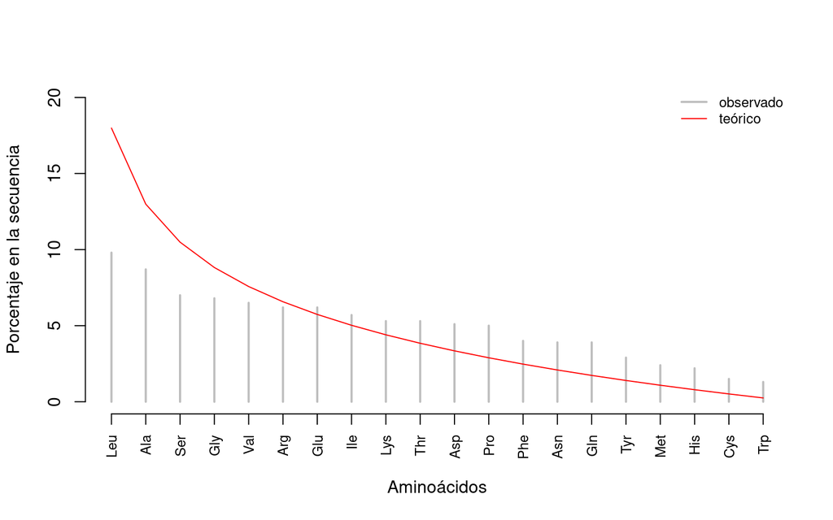

```r
AAn <- c("Leu", "Ala", "Ser", "Gly", "Val", "Arg", "Glu", "Ile", "Lys", "Thr", "Asp",
    "Pro", "Phe", "Asn", "Gln", "Tyr", "Met", "His", "Cys", "Trp")
AAp <- c(9.8, 8.7, 7, 6.8, 6.5, 6.2, 6.2, 5.7, 5.3, 5.3, 5.1, 5, 4, 3.9, 3.9, 2.9,
    2.4, 2.2, 1.5, 1.3)
n <- 20
plot(AAp, type = "h", lwd = 2, bty = "n", xaxt = "n", xlab = "Aminoácidos", ylab = "Porcentaje en la secuencia",
    col = "grey", ylim = c(0, 20))
axis(1, at = 1:20, labels = AAn, las = 2, cex.axis = 0.8)
lines(100 * sum_arm(n), col = "red")
legend("topright", bty = "n", cex = 0.8, c("observado", "teórico"), lwd = c(2, 1),
    col = c("grey", "red"))
```

No obstante, parece que cuando los aminoácidos se agrupan funcionalmente (hidrofóbicos, polares y aromáticos), el reparto aleatorio dentro de cada grupo explica bastante bien la distribución, según explican [estos japoneses](https://www.researchgate.net/publication/15756881_The_broken-stick_model_for_amino_acid_composition_in_proteins). Si he entendido bien, esto significa que la posición en la proteína depende de la función que puede desempeñar el ŕesiduo, más que de su nombre. Esto mismo ocurre en los ecosistemas: el papel del ciervo europeo lo desempeña el canguro australiano, por ejemplo.

# Aplicado a las metioninas

> Supongamos que hay $n+1$ metioninas repartidas al azar en la secuencia de la proteína. Entonces, las $n$ distancias entre ellas deben seguir la distribución del bastón roto.

En esta analogía, el segmento completo de longitud 1 representa la distancia entre la primera metionina y la última, en vez de la longitud total de la proteína.

Veamos cómo se distribuyen las 18 metionias en [esta proteína](https://metosite.uma.es/scan/A0AVT1) cuya secuencia he sacado de la magnífica base de datos que Héctor, Paco y Juan Carlos han puesto a disposición de todo el mundo.

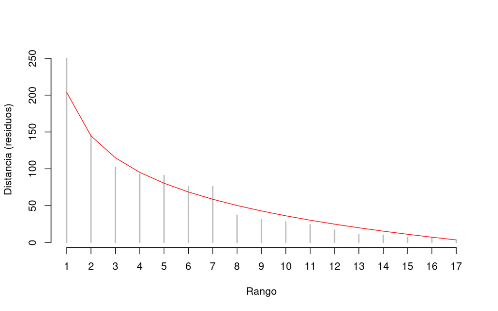

```r
sec <- "MEGSEPVAAHQGEEASCSSWGTGSTNKNLPIMSTASVEIDDALYSRQRYVLGDTAMQKMA…"
mets <- unlist(gregexpr("M", sec))
n <- length(mets) - 1
distancias <- numeric(n)
for (i in 1:n) {
    distancias[i] <- mets[i + 1] - mets[i]
}
distancias <- sort(distancias, decreasing = TRUE)
plot(distancias, type = "h", lwd = 2, col = "grey", bty = "n", xaxt = "n", xlab = "Rango",
    ylab = "Distancia (residuos)", xlim = c(1, 17))
axis(1, at = 1:n, labels = 1:n)
longitud <- sum(distancias)
lines(longitud * sum_arm(n), col = "red")
```

**Figura 9. Distancias entre metioninas en la proteína A0AVT1 ordenadas de mayor a menor.** Las barras representan las distancias entre dos metioninas consecutivas (en número de residuos) y la línea roja las distancias esperadas según el modelo teórico. ¿Se parecen lo suficiente?

## Tests estadísticos

Así, a ojo, diría que sí pero vamos a asegurarnos. Construiremos una distribución de probabilidad mediante el método de Montecarlo, a ver dónde cae esta proteína.

### Estadístico: suma de diferencias absolutas

Consideremos el estadístico

$$d = \sum_{r=1}^{n} \left| m_r - a_r \right|$$
donde $r$, como antes, es el rango de mayor a menor y $m_r$ es la distancia de rango $r$ observada en la proteína, siendo $a_r$ la distancia teórica definida al principio. Calculemos a lo bestia la distribución de $d$ cuando se cumple la hipótesis de reparto aleatorio:

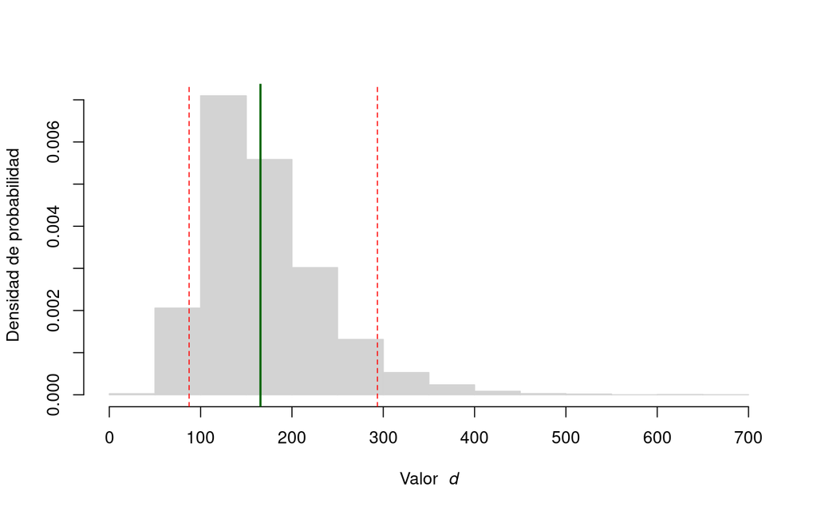

```r
# primero calculamos 'd' observada en la proteína
d <- sum(abs(distancias - longitud * sum_arm(n)))
# ahora construimos la distribución de probabilidad
repetir <- 10000
dS <- numeric(repetir)
distanciaa <- numeric(n)
for (j in 1:repetir) {
    p_azar <- nchar(sec) * runif(n + 1)  # elegir los puntos de corte al azar
    p_azar <- sort(p_azar)  # ordenar los cortes
    for (i in 1:n) {
        distanciaa[i] <- p_azar[i + 1] - p_azar[i]
    }
    distanciaa <- sort(distanciaa, decreasing = TRUE)
    longitua <- sum(distanciaa)
    dS[j] <- sum(abs(distanciaa - longitua * sum_arm(n)))
}
# calculamos donde cae el valor observado 'd'
probd <- sum(dS <= d)/repetir
# dibujamos el histograma
hist(dS, freq = FALSE, main = "", border = "lightgrey", xlab = expression("Valor " ~
    italic(d)), ylab = "Densidad de probabilidad")
# vemos dónde quedan los límites de confianza clásicos
limites <- quantile(dS, probs = c(0.05, 0.95))
abline(v = limites, col = "red", lty = 2)
# y dibujamos el valor observado 'd' en la proteína
abline(v = d, col = "darkgreen", lwd = 2)
```

**Figura 10. Distribución de probabilidad y valor del estadístico $d$ en la proteína A0AVT1.** Las barras rojas representan los cuartiles $0.05 < p < 0.95$ y la barra verde el valor observado en la proteína, $d = 166$ cuya probabilidad es $p < 0.56$.

### Estadístico: coeficiente de determinación

Consideremos ahora

$$\rho^2 = 1 - \frac{1}{(n-1)s^2}\sum_{r=1}^{n} (m_r - a_r)^2$$
donde $s^2$ es la varianza de las distancias observadas. La fórmula es más compleja que su significado intuitivo: la fracción de varianza que es explicada por el modelo teórico. Veamos:

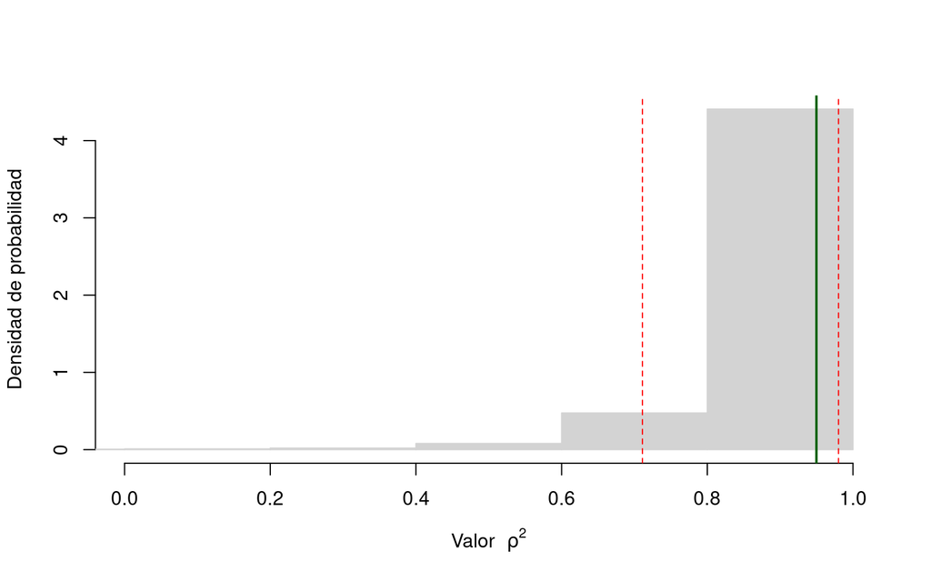

```r
# primero calculamos 'rho' observada en la proteína
rho <- 1 - (sum((distancias - longitud * sum_arm(n))^2)/((n - 1) * var(distancias)))
# ahora construimos la distribución de probabilidad
repetir <- 10000
rhoS <- numeric(repetir)
distanciaar <- numeric(n)
for (j in 1:repetir) {
    p_azar <- nchar(sec) * runif(n + 1)  # elegir los puntos de corte al azar
    p_azar <- sort(p_azar)  # ordenar los cortes
    for (i in 1:n) {
        distanciaar[i] <- p_azar[i + 1] - p_azar[i]
    }
    distanciaar <- sort(distanciaar, decreasing = TRUE)
    longituar <- sum(distanciaar)
    rhoS[j] <- 1 - (sum((distanciaar - longituar * sum_arm(n))^2)/((n - 1) * var(distanciaar)))
}
# calculamos donde cae el valor observado 'rho'
probrho <- sum(rhoS <= rho)/repetir
# dibujamos el histograma
hist(rhoS, freq = FALSE, main = "", border = "lightgrey", xlab = expression("Valor " ~
    italic(rho)^2), ylab = "Densidad de probabilidad", xlim = c(0, 1))
# vemos dónde quedan los límites de confianza clásicos
limites <- quantile(rhoS, probs = c(0.05, 0.95))
abline(v = limites, col = "red", lty = 2)
# y dibujamos el valor observado 'rho' en la proteína
abline(v = rho, col = "darkgreen", lwd = 2)
```

**Figura 11. Distribución de probabilidad del estadístico $\rho^2$ y valor en la proteína A0AVT1.** La barras tienen el mismo significado que en la figura anterior. Esta prueba parece menos precisa que la anterior porque acumula muchos casos cerca de la cola derecha derecho que, de hecho, no es cola pues parece terminar abruptamente.

### Estadístico: distancia de Kolmogorov-Smirnov

Consideremos ahora este otro

$$D = max \left| F(m_r) - F(a_r) \right|$$

creo que la nomenclatura no es muy correcta, pero significa *la máxima distancia entre las funciones acumuladas observada y teórica*.

Veamos:

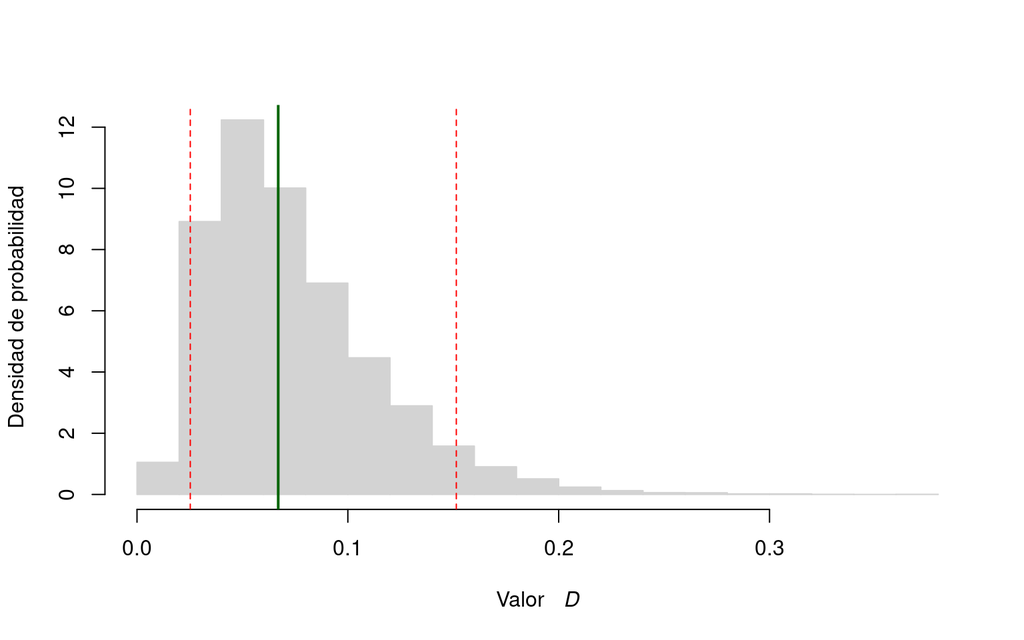

```r
# primero calculamos 'Dks' observada en la proteína
Dks <- max(abs(cumsum(distancias)/longitud - cumsum(sum_arm(n))))
# ahora construimos la distribución de probabilidad
repetir <- 10000
DksS <- numeric(repetir)
distanciaks <- numeric(n)
for (j in 1:repetir) {
    p_azar <- nchar(sec) * runif(n + 1)  # elegir los puntos de corte al azar
    p_azar <- sort(p_azar)  # ordenar los cortes
    for (i in 1:n) {
        distanciaks[i] <- p_azar[i + 1] - p_azar[i]
    }
    distanciaks <- sort(distanciaks, decreasing = TRUE)
    longituks <- sum(distanciaks)
    DksS[j] <- max(abs(cumsum(distanciaks)/longituks - cumsum(sum_arm(n))))
}
# calculamos donde cae el valor observado 'rho'
probDks <- sum(DksS <= Dks)/repetir
# dibujamos el histograma
hist(DksS, freq = FALSE, main = "", border = "lightgrey", xlab = expression("Valor  " ~
    italic(D)), ylab = "Densidad de probabilidad")
# vemos dónde quedan los límites de confianza clásicos
limites <- quantile(DksS, probs = c(0.05, 0.95))
abline(v = limites, col = "red", lty = 2)
# y dibujamos el valor observado 'rho' en la proteína
abline(v = Dks, col = "darkgreen", lwd = 2)
```

**Figura 12. Distribución de probabilidad del estadístico $D$ y valor en la proteína A0AVT1.** Las barras rojas representan los cuartiles $0.05 < p < 0.95$ y la barra verde el valor observado en la proteína, $D = 0.07$ cuya probabilidad es $p < 0.52$. Se parece mucho a la distribución del primer estadístico que probamos.

## Agregación o sobredispersión

Los tres estadísticos anteriores son capaces de identificar una muestra que cumpla la hipótesis de posición al azar. Sin embargo, cuando una proteína tenga las metioninas agrupadas o excepcionalmente espaciadas, ninguno de los tres podrá distinguir entre ambos porque los dos se manifestarán con un elevado valor del estadístico.

He estado pensando algunas pruebas basadas la distribución protagonista, pero no he encontrado ninguna que mejore el conocido test de agregación/dispersión basado en varianza y media:

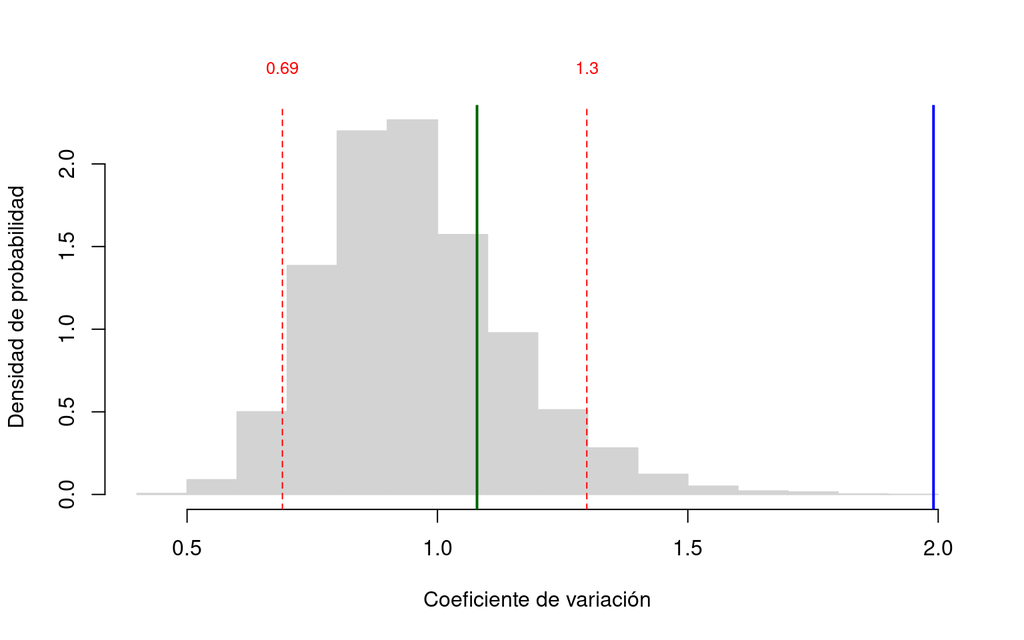

```r
# función suma de armónicos
sum_arm <- function(n) {
    a <- numeric(n)
    for (i in 1:n) {
        for (j in 1:i) {
            a[j] <- a[j] + 1/i
        }
    }
    a/n
}

sec <- "MEGSEPVAAHQGEEASCSSWGTGSTNKNLPIMSTASVEIDDALYSRQRYVLGDTAMQKMA…"
longitud <- nchar(sec)
mets <- c(unlist(gregexpr("M", sec)), longitud)
n <- length(mets)
trozos <- numeric(n)
for (i in 1:n) {
    trozos[i] <- mets[i + 1] - mets[i]
}
trozos <- sort(trozos, decreasing = TRUE)

# prueba estadística (coeficiente de variación) distribución de probabilidad
repetir <- 10000
cvS <- numeric(repetir)
trozosS <- numeric(n)
for (j in 1:repetir) {
    p_azar <- longitud * runif(n + 1)  # elegir los puntos de corte al azar
    p_azar <- sort(p_azar)  # ordenar los cortes
    for (i in 1:n) {
        trozosS[i] <- p_azar[i + 1] - p_azar[i]
    }
    trozosS <- sort(trozosS, decreasing = TRUE)
    longitua <- sum(trozosS)
    cvS[j] <- sd(trozosS)/mean(trozosS)
}
# calculamos donde cae el valor observado 'd' probd <- sum(dS<= d)/repetir
# dibujamos el histograma
hist(cvS, freq = FALSE, main = "", border = "lightgrey", xlab = expression("Coeficiente de variación"),
    ylab = "Densidad de probabilidad")
# maxy <- par('usr')[4] vemos dónde quedan los límites de confianza clásicos
limites <- quantile(cvS, probs = c(0.05, 0.95))
abline(v = limites, col = "red", lty = 2)
axis(3, at = limites, labels = round(limites, 2), lwd = 0, cex.axis = 0.8, col.axis = "red")

# calculamos cv en la proteína y lo representamos
cvP <- sd(trozos)/mean(trozos)
abline(v = cvP, col = "darkgreen", lwd = 2)

# una proteína con todas la metioninas equidistantes tendría un cv = 0

# una proteína con 18 metioninas centrales agregadas tendría ?
dist_ag <- numeric()
posiciones_met <- c(1, round(rnorm(n - 1, mean = 500, sd = 100)), longitud)
posiciones_met <- sort(posiciones_met)
for (i in 1:n) {
    dist_ag[i] <- posiciones_met[i + 1] - posiciones_met[i]
}
cvA <- sd(dist_ag)/mean(dist_ag)
abline(v = cvA, col = "blue", lwd = 2)
```

**Figura 13. Distribución de probabilidad del coeficiente de variación y valor en la proteína A0AVT1.** Las barras rojas representan los cuartiles $0.05 < p < 0.95$ y la barra verde el valor observado en la proteína, $D = 1.08$. La barra azul representa el valor del $cv$ de una proteína con 18 metioninas agrupadas en el centro de la proteína.